# Maine COVID19 By County

The Maine CDC COVID19 [information site](https://www.maine.gov/dhhs/mecdc/infectious-disease/epi/airborne/coronavirus.shtml) is a wonderful resource for getting updated info. The site provides a number of tables with counts of cases by county, age and sex. The site also provides a map of cases by county which is interesting, but misses the importantance normalizing counts by population. This note attempts to augment the state case by county map with a case density by county map companion using [tidyverse tools](https://www.tidyverse.org/) (and friends).

We first retrieve the most recent census info (10 years old now) from the Maine State economist’s office. The office published spreadsheets of population by [county](https://www.maine.gov/economist/state/pub/ME-Pop-County-2010.xls)

```r
suppressPackageStartupMessages(library(dplyr))
suppressPackageStartupMessages(library(readxl))
suppressPackageStartupMessages(library(rvest))
suppressPackageStartupMessages(library(xml2))
suppressPackageStartupMessages(library(sf))
suppressPackageStartupMessages(library(USAboundaries))
suppressPackageStartupMessages(library(ggplot2))
suppressPackageStartupMessages(library(patchwork))
```

Shown below are the steps to gather the data, but to keep things simple the steps are commented out and only the result becomes an R variable. It’s an excel file; these are easy to read using [readxl](https://readxl.tidyverse.org/)

```r
#MePop<- readxl::read_xls("~/Downloads/ME-Pop-County-2010.xls") %>%
#  dplyr::select(1:2)
#colnames(MePop) <- c("County", "Pop2010")
#MePop <- v %>% arrange(County)
#dput(MePop)
MePop <- structure(list(County = c("Androscoggin", "Aroostook", "Cumberland",
"Franklin", "Hancock", "Kennebec", "Knox", "Lincoln", "Oxford",
"Penobscot", "Piscataquis", "Sagadahoc", "Somerset", "Waldo",
"Washington", "York"), Pop2010 = c(107702, 71870, 281674, 30768,
54418, 122151, 39736, 34457, 57833, 153923, 17535, 35293, 52228,
38786, 32856, 197131)), row.names = c(NA, -16L), class = c("tbl_df",
"tbl", "data.frame"))
```

Next we use web-scraping tools to fetch the table from the website. [rvest](http://rvest.tidyverse.org/) makes this easy.

```r
uri <- "https://www.maine.gov/dhhs/mecdc/infectious-disease/epi/airborne/coronavirus.shtml"
MeCDC <- xml2::read_html(uri)
```

Like many HTML tables, the table itself is messy - great for reading online but annoying to parse for computation. Through trial and error the correct table identified (it’s currently the third table on the page.)

```r
tbl <- MeCDC %>%
  rvest::html_nodes("table") %>%
  .[[3]] %>%
  rvest::html_table()
str(tbl)
```

```
## 'data.frame':    18 obs. of  5 variables:
##  $ Cumulative COVID‑19 Case Counts by County: chr  "County" "Androscoggin" "Aroostook" "Cumberland" ...
##  $ Cumulative COVID‑19 Case Counts by County: chr  "Confirmed" "32" "2" "360" ...
##  $ Cumulative COVID‑19 Case Counts by County: chr  "Recovered" "13" "1" "181" ...
##  $ Cumulative COVID‑19 Case Counts by County: chr  "Hospitalizations" "11" "" "56" ...
##  $ Cumulative COVID‑19 Case Counts by County: chr  "Deaths" "1" "" "14" ...
```

Uggg. The column names are repeats of the table name, and the first row has the actual column names.

So, we will do some back flips to rename the column. Then we will convert the counts columns to numerics, followed by ordering alphabetically and merging in the population counts. Finally, we add a density column (per 1000 people) using a function - each new column name is prepended with “d” for density.

```r
colnames(tbl) <- gsub("[0-9]", "", unname(as.vector(tbl[1,])))
x <- tbl[-1,] %>%
  dplyr::as_tibble() %>%
  dplyr::mutate_at(colnames(tbl)[-1], as.numeric) %>%
  dplyr::arrange(County) %>%
  dplyr::left_join(MePop, by = "County") %>%
  dplyr::mutate(
    dConfirmed = Confirmed/(Pop2010/1000),
    dRecovered = Recovered/(Pop2010/1000),
    dHospitalizations = Hospitalizations/(Pop2010/1000),
    dDeaths  = Deaths/(Pop2010/1000)
  )
x
```

| County | Confirmed | Recovered | Hospitalizations | Deaths | Pop2010 | dConfirmed | dRecovered | dHospitalizations | dDeaths |
| --- | --- | --- | --- | --- | --- | --- | --- | --- | --- |
| Androscoggin | 32 | 13 | 11 | 1 | 107702 | 0.29711612 | 0.12070342 | 0.10213367 | 0.009284879 |
| Aroostook | 2 | 1 | NA | NA | 71870 | 0.02782802 | 0.01391401 | NA | NA |
| Cumberland | 360 | 181 | 56 | 14 | 281674 | 1.27807323 | 0.64258682 | 0.19881139 | 0.049702848 |
| Franklin | 10 | 4 | 1 | NA | 30768 | 0.32501300 | 0.13000520 | 0.03250130 | NA |
| Hancock | 6 | 1 | 1 | NA | 54418 | 0.11025764 | 0.01837627 | 0.01837627 | NA |
| Kennebec | 95 | 16 | 14 | 3 | 122151 | 0.77772593 | 0.13098542 | 0.11461224 | 0.024559766 |
| Knox | 12 | 5 | 1 | NA | 39736 | 0.30199315 | 0.12583048 | 0.02516610 | NA |
| Lincoln | 12 | 7 | NA | NA | 34457 | 0.34826015 | 0.20315175 | NA | NA |
| Oxford | 13 | 8 | 1 | NA | 57833 | 0.22478516 | 0.13832933 | 0.01729117 | NA |
| Penobscot | 40 | 25 | 7 | NA | 153923 | 0.25987019 | 0.16241887 | 0.04547728 | NA |

[output cut: 7 more lines]

Phew!

Now let’s make side-by-side plots of counts by county and density by county. First we need to get county geometries from USAboundaries. We then merge with our table above.

```r
x <- USAboundaries::us_counties(states = "Maine", resolution = "high") %>%
  dplyr::select(name, geometry) %>%
  dplyr::rename(County = 'name') %>%
  dplyr::arrange(County) %>%
  dplyr::left_join(x, by = "County")
x
```

| County | Confirmed | Recovered | Hospitalizations | Deaths | Pop2010 | dConfirmed | dRecovered | dHospitalizations | dDeaths | geometry |
| --- | --- | --- | --- | --- | --- | --- | --- | --- | --- | --- |
| Androscoggin | 32 | 13 | 11 | 1 | 107702 | 0.29711612 | 0.12070342 | 0.10213367 | 0.009284879 |  |
| Aroostook | 2 | 1 | NA | NA | 71870 | 0.02782802 | 0.01391401 | NA | NA |  |
| Cumberland | 360 | 181 | 56 | 14 | 281674 | 1.27807323 | 0.64258682 | 0.19881139 | 0.049702848 |  |
| Franklin | 10 | 4 | 1 | NA | 30768 | 0.32501300 | 0.13000520 | 0.03250130 | NA |  |
| Hancock | 6 | 1 | 1 | NA | 54418 | 0.11025764 | 0.01837627 | 0.01837627 | NA |  |
| Kennebec | 95 | 16 | 14 | 3 | 122151 | 0.77772593 | 0.13098542 | 0.11461224 | 0.024559766 |  |
| Knox | 12 | 5 | 1 | NA | 39736 | 0.30199315 | 0.12583048 | 0.02516610 | NA |  |
| Lincoln | 12 | 7 | NA | NA | 34457 | 0.34826015 | 0.20315175 | NA | NA |  |
| Oxford | 13 | 8 | 1 | NA | 57833 | 0.22478516 | 0.13832933 | 0.01729117 | NA |  |
| Penobscot | 40 | 25 | 7 | NA | 153923 | 0.25987019 | 0.16241887 | 0.04547728 | NA |  |

[output cut: 6 more lines]

Now we plot the two side by side using [ggplot2](https://ggplot2.tidyverse.org) and patchwork.

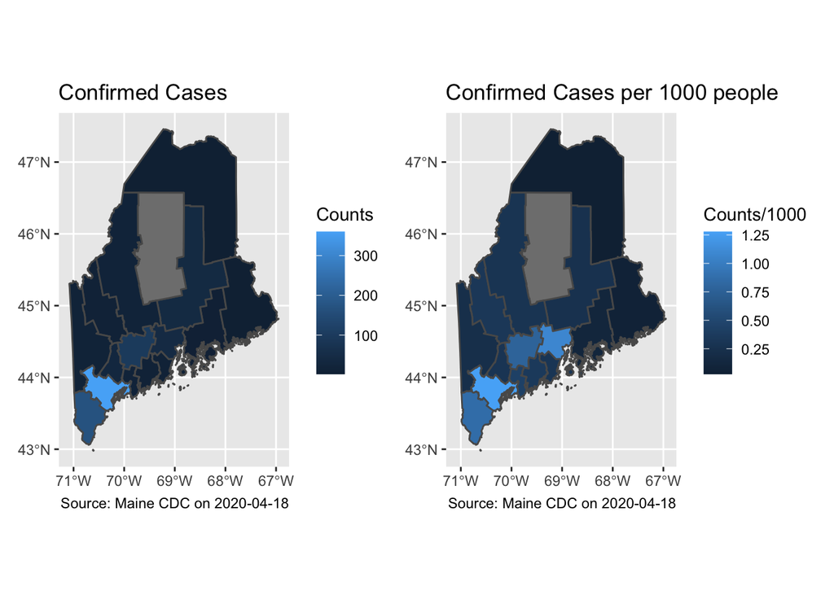